# **Analysis of the level of DNA methylation in a dataset with R**

Federica Brando

20/06/20

Abstract

This report describes the pipeline for module 2 final assignment of DNA and RNA dynamics course of University of Bologna master’s degree in Bioinformatics. Each main chapter corresponds to each step, briefly commented and explained. The dataset consists in eight samples: 4 belonging to down syndrome `DS` group and four wild-type `WT`. The aim of this report is to illustrate how to perform the analysis of the level of methylation in a given dataset with R.

# 1 **Loading raw data**

The first step of the workflow is to load and read raw data with `minfi` library. `minfi` is a very useful and complete library of tools for analyzing and visualizing Illumina methylation array data with a special focus on the 450k array. So, we load the `Illumina450Manifest_clean.RData` and read the data stored in `./Input_data` directory with `minfi` function `read.metharray.sheet()` .

```r
rm(list=ls())  # clean the workspace
setwd("~/PycharmProjects/drd/Report")  # set the working directory
library(minfi)  # load minfi package
load('~/PycharmProjects/drd/Lesson2/Illumina450Manifest_clean.RData')  # load the illumina manifest

baseDir <- ("~/PycharmProjects/drd/Report/Input_data")  # set the data directory
targets <- read.metharray.sheet(baseDir)  # reading the sample sheet containing pheno-data
```

```
[1] "/home/fecke/PycharmProjects/drd/Report/Input_data/Samplesheet_report_2020.csv"
```

```r
targets
```

| Sample_Name | Group | Age | Slide | Array | Basename |
| --- | --- | --- | --- | --- | --- |
| 1020 | DS | 29 | 5775278051 | R01C01 | /home/fecke/PycharmProjects/drd/Report/Input_data/5775278051_R01C01 |
| 1036 | DS | 34 | 5775278051 | R04C02 | /home/fecke/PycharmProjects/drd/Report/Input_data/5775278051_R04C02 |
| 3038 | WT | 46 | 5775278078 | R02C01 | /home/fecke/PycharmProjects/drd/Report/Input_data/5775278078_R02C01 |
| 3042 | WT | 32 | 5775278078 | R05C01 | /home/fecke/PycharmProjects/drd/Report/Input_data/5775278078_R05C01 |
| 3052 | WT | 31 | 5775278078 | R05C02 | /home/fecke/PycharmProjects/drd/Report/Input_data/5775278078_R05C02 |
| 1016 | DS | 43 | 5930514034 | R01C02 | /home/fecke/PycharmProjects/drd/Report/Input_data/5930514034_R01C02 |
| 1029 | DS | 32 | 5930514035 | R04C02 | /home/fecke/PycharmProjects/drd/Report/Input_data/5930514035_R04C02 |
| 3029 | WT | 35 | 5930514035 | R06C02 | /home/fecke/PycharmProjects/drd/Report/Input_data/5930514035_R06C02 |

Then we create a variable in which we store the `RGChannelSet` object.

```r
# reading methylation array data {class:RGChannelSet}
RGset <- read.metharray.exp(targets = targets)
RGset
```

```
class: RGChannelSet
dim: 622399 8
metadata(0):
assays(2): Green Red
rownames(622399): 10600313 10600322 ... 74810490 74810492
rowData names(0):
colnames(8): 5775278051_R01C01 5775278051_R04C02 ... 5930514035_R04C02
  5930514035_R06C02
colData names(7): Sample_Name Group ... Basename filenames
Annotation
  array: IlluminaHumanMethylation450k
  annotation: ilmn12.hg19
```

# 2 **Red and Green fluorescence**

The second step is to create a `data.frame` for Red and Green fluorescence respectively.

```r
# Red dataframe
Red <- data.frame(getRed(RGset))
head(Red)
```

|  | X5775278051_R01C01 | X5775278051_R04C02 | X5775278078_R02C01 | X5775278078_R05C01 | X5775278078_R05C02 | X5930514034_R01C02 | X5930514035_R04C02 | X5930514035_R06C02 |
| --- | --- | --- | --- | --- | --- | --- | --- | --- |
| 10600313 | 816 | 1055 | 603 | 647 | 583 | 441 | 463 | 606 |
| 10600322 | 2269 | 2965 | 1840 | 2103 | 2228 | 1383 | 1823 | 2315 |
| 10600328 | 1673 | 2500 | 1420 | 1588 | 1600 | 3456 | 2773 | 2540 |
| 10600336 | 18318 | 21740 | 16924 | 17981 | 16158 | 16169 | 18221 | 19048 |
| 10600345 | 4141 | 4575 | 3198 | 3123 | 3233 | 3424 | 3336 | 3595 |
| 10600353 | 1433 | 1680 | 1228 | 1211 | 1141 | 1164 | 975 | 1136 |

```r
# Green dataframe
Green <- data.frame(getGreen(RGset))
head(Green)
```

|  | X5775278051_R01C01 | X5775278051_R04C02 | X5775278078_R02C01 | X5775278078_R05C01 | X5775278078_R05C02 | X5930514034_R01C02 | X5930514035_R04C02 | X5930514035_R06C02 |
| --- | --- | --- | --- | --- | --- | --- | --- | --- |
| 10600313 | 373 | 494 | 278 | 360 | 321 | 210 | 198 | 350 |
| 10600322 | 7413 | 10620 | 6667 | 8362 | 7963 | 6896 | 8344 | 9709 |
| 10600328 | 2369 | 2375 | 1995 | 2179 | 2401 | 2954 | 3222 | 2806 |
| 10600336 | 1734 | 2060 | 1456 | 1775 | 1757 | 1152 | 1702 | 1617 |
| 10600345 | 3400 | 4416 | 3590 | 3665 | 3559 | 2975 | 3516 | 4530 |
| 10600353 | 4233 | 4873 | 3790 | 3406 | 3693 | 2973 | 3371 | 3983 |

# 3 **Fluorescence inspection**

> **Q**: What are the Red and Green fluorescence for `42639338`?

In order to answer this question we can inspect the `data.frame` just created with the following:

```r
Red[rownames(Red)=="42639338",]
```

|  | X5775278051_R01C01 | X5775278051_R04C02 | X5775278078_R02C01 | X5775278078_R05C01 | X5775278078_R05C02 | X5930514034_R01C02 | X5930514035_R04C02 | X5930514035_R06C02 |
| --- | --- | --- | --- | --- | --- | --- | --- | --- |
| 42639338 | 14046 | 17095 | 10490 | 14706 | 12822 | 13961 | 16314 | 15172 |

```r
Green[rownames(Green)=="42639338",]
```

|  | X5775278051_R01C01 | X5775278051_R04C02 | X5775278078_R02C01 | X5775278078_R05C01 | X5775278078_R05C02 | X5930514034_R01C02 | X5930514035_R04C02 | X5930514035_R06C02 |
| --- | --- | --- | --- | --- | --- | --- | --- | --- |
| 42639338 | 12057 | 12635 | 10730 | 12498 | 12067 | 10900 | 12788 | 14474 |

## 3.1 *Optional*: Design probe inspection

We can retrieve information on the probe design by checking the address we previously used to the manifest file and eventually, if design probe is Type I, report the color.

```r
Addr42639338 <- Illumina450Manifest_clean[Illumina450Manifest_clean$AddressA_ID=="42639338",]
Addr42639338$Infinium_Design_Type
```

```
[1] "II"
```

```
II
```

The result shows that the probe design is a type II probe, therefore we would not find a color assigned to it.

## 3.2 Table recap

[output not shown]

# 4 **Creating methylation signal object**

Next step is to convert the `RGChannelSet` object into a `MethylSet` object. The latter contains the methylated and unmethylated signals of our data. We use the `preprocessRaw()` function to perform this task.

```r
MSet.raw <- preprocessRaw(RGset)  # Create a MSet.raw object
MSet.raw
```

```
class: MethylSet
dim: 485512 8
metadata(0):
assays(2): Meth Unmeth
rownames(485512): cg00050873 cg00212031 ... ch.22.47579720R
  ch.22.48274842R
rowData names(0):
colnames(8): 5775278051_R01C01 5775278051_R04C02 ... 5930514035_R04C02
  5930514035_R06C02
colData names(7): Sample_Name Group ... Basename filenames
Annotation
  array: IlluminaHumanMethylation450k
  annotation: ilmn12.hg19
Preprocessing
  Method: Raw (no normalization or bg correction)
  minfi version: 1.34.0
  Manifest version: 0.4.0
```

# 5 **Quality check**

Next step in the workflow is to evaluate the *quality* of the data. We can do this by performing three types of quality checks:

1. **QCplot**
2. **Negative controls intensity check**
3. **Detection of pValues**

## 5.1 *QCplot*

A QCplot is a plot in which we plot the median of the methylation signal and the median of the unmethylation signal for each sample. If the samples have good quality, high medians for both methylation and unmethylation signals, they would be found in the upper part of the plot, otherwise we find them in the lower region of the plot and we consider them as low-quality samples.

We use the `getQC()` function to extract the aforementioned median values and `plotQC()` function to plot them.

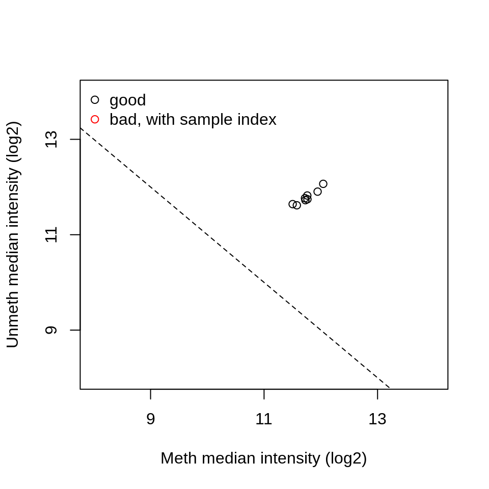

**Figure 1**: QC plot

```r
qc <- getQC(MSet.raw)
plotQC(qc)
```

In this case we can affirm that samples have **good quality**, indeed they are located in the upper region of the plot, so they have high median methylation and unmethylation values.

## 5.2 *Negative control intensity check*

These check is useful to understand the quality of negative controls. If it returns high green or red fluorescence then the background fluorescence is indistinguishable from the real signal and indicates poor sample quality. The background level intensity is at 10 ( $\log{2}$ ), therefore below that threshold we consider the samples to have a good quality. otherwise we don’t.

We use the function `controlStripPlot()` to obtain the result (**Fig.2** below). We can also observe that the samples maintain a consistent intensity variation between slides, that is reproducible for both red and green, and they are all below background level (10).

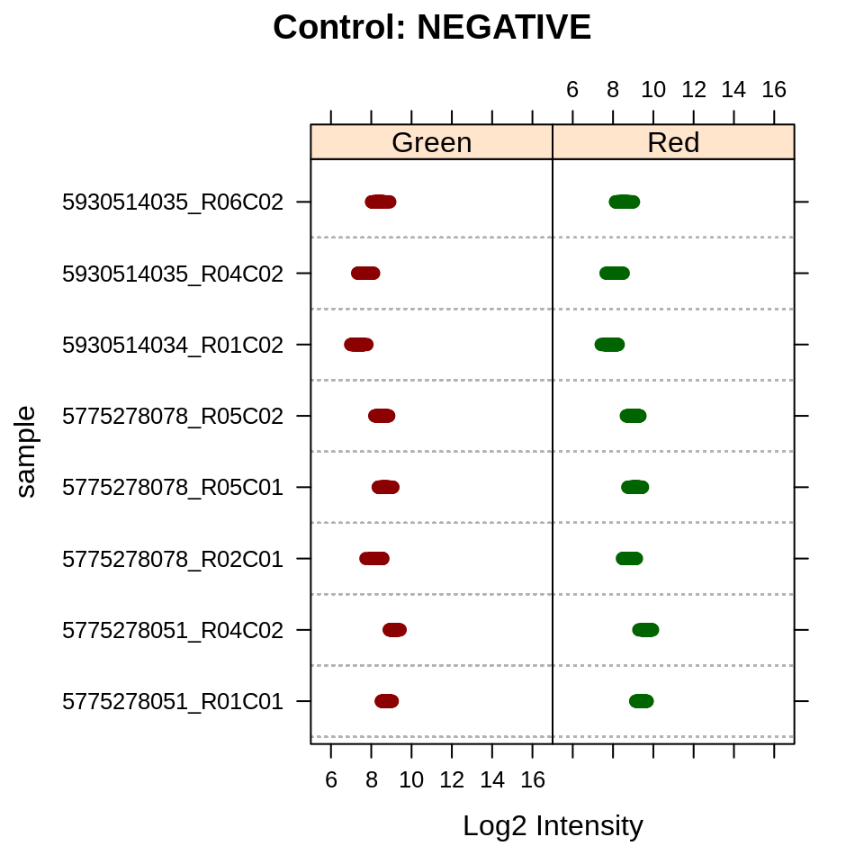

**Figure 2**: Negative control check.

```r
controlStripPlot(RGset, controls="NEGATIVE")
```

## 5.3 *Detection of pValues*

> **Q**: for each sample, how many probes have a detection p-value higher than the threshold `0.05`?

The detection of p-values points out the probability that the signal we are observing in the data is different from the background. The null hypotheses states that signal are equal, the alternative hypotheses states that the signals differ from each other. Indeed, small p-values indicate good position, we can reject the null hypotheses and state that the signal is different from the background with high confidence.

To perform this task we use `detectionP()` function on `RGset` to obtain the p-Values. We store the probes with p-Value higher than the assigned threshold in `failed` variable and then we inspect it to retrieve the number of those probes per sample.

```r
detP <- detectionP(RGset)

failed <- detP>0.05
summary(failed)  # True probes have a p-value > 0.05
```

```
 5775278051_R01C01 5775278051_R04C02 5775278078_R02C01 5775278078_R05C01
 Mode :logical     Mode :logical     Mode :logical     Mode :logical
 FALSE:485265      FALSE:485302      FALSE:485248      FALSE:485099
 TRUE :247         TRUE :210         TRUE :264         TRUE :413
 5775278078_R05C02 5930514034_R01C02 5930514035_R04C02 5930514035_R06C02
 Mode :logical     Mode :logical     Mode :logical     Mode :logical
 FALSE:485127      FALSE:485421      FALSE:485466      FALSE:485397
 TRUE :385         TRUE :91          TRUE :46          TRUE :115
```

### 5.3.1 Table recap

[output not shown]

# 6 **Computing raw $\beta$ and M values**

Raw $\beta$ and M are computed as: $\beta = \frac{M}{M+U}$ and $M = \log_{2}(\frac{M}{U})$. $\beta$ is a value that expresses the level of methylation at a given CpG site, it ranges between 0 and 1, where 1 stands for completely methylated and 0 stands for the opposite. M, instead, is a variable that can take any value of the real line.

We can plot the densities of continuous variable of $\beta$ and M to observe the level of methylation in the sample. In our sample we can subset the dataset accordingly to the groups: `DS` and `WT`.

In order to extract $\beta$ and M values we can use the functions `getBeta()` and `getM()` respectively, on both `DS` and `WT` subsets. We then compute `mean` and `density` in order to plot the results.

```r
# reading the data
csvtargets <- read.csv("Input_data/Samplesheet_report_2020.csv")

#WT
WT <- csvtargets[csvtargets$Group=="WT", "Basename"]
WTSet <- MSet.raw[,colnames(MSet.raw) %in% WT]
BetaWT <- getBeta(WTSet)  # getting beta values
M_WT <- getM(WTSet)  # getting M values
meanBeta_WT <- apply(BetaWT, 1, mean, na.rm=T)
meanM_WT <- apply(M_WT, 1, mean, na.rm=T)
d_meanBeta_WT <- density(meanBeta_WT)
d_meanM_WT <- density(meanM_WT)

#DS
DS <- csvtargets[csvtargets$Group=="DS", "Basename"]
DSSet <- MSet.raw[,colnames(MSet.raw) %in% DS]
BetaDS <- getBeta(DSSet)
M_DS <- getM(DSSet)
meanBeta_DS <- apply(BetaDS, 1, mean, na.rm=T)
meanM_DS <- apply(M_DS, 1, mean, na.rm=T)
d_meanBeta_DS <- density(meanBeta_DS)
d_meanM_DS <- density(meanM_DS)
```

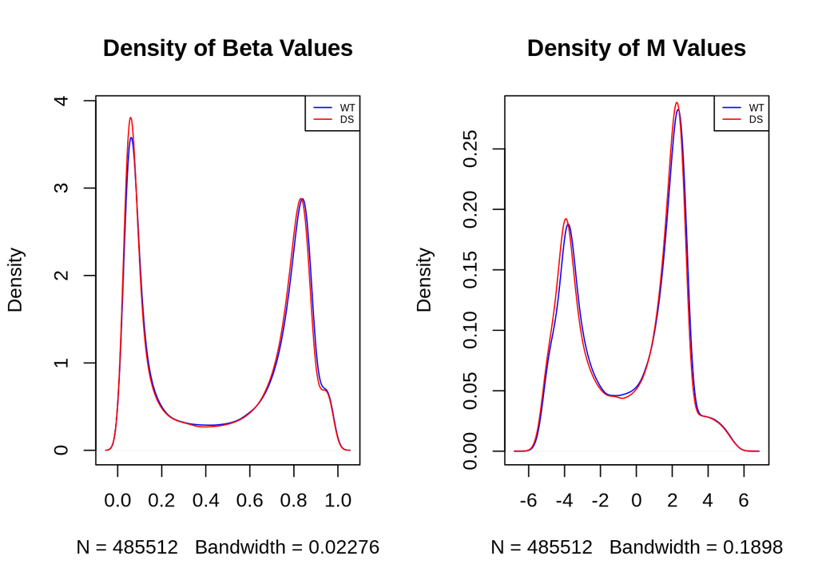

**Figure 3**: (left) beta plot for subset WT and DS, (right) M plot for subset WT and DS

```r
par(mfrow=c(1,2))
plot(d_meanBeta_WT,main="Density of Beta Values",col="blue", ylim = c(-0.01, 3.9))
lines(d_meanBeta_DS, col="red")
legend("topright", legend=c("WT", "DS"),
       col=c("blue", "red"), lty=1:1, cex=0.5)
plot(d_meanM_WT,main="Density of M Values",col="blue")
lines(d_meanM_DS, col='red')
legend("topright", legend=c("WT", "DS"),
       col=c("blue", "red"), lty=1:1, cex=0.5)
```

The inspection of the plot shows that the two subsets `WT` and `DS` have similar distribution. We can note a slightly higher peak for `DS` group for the beta values, other that that they follow the same trend.

# 7 **Normalization**

Data as it is right now cannot be compared, therefore we need to normalize it in order to get rid of technical variation and systematic bias. We normalize using the function `preprocessQuantile()`, this function is a stratified quantile normalization, it stratifies the probe by region and returns the $\beta$ values normalized. We, then, compare raw data and normalize data from Infinium I and II design.

First, we retrieve all the raw $\beta$ values from `MSet.raw`, then we normalize data from `RGset` and extract normalized $\beta$ from it.

```r
beta <- getBeta(MSet.raw)

preprocessQuantile_results <- preprocessQuantile(RGset)
preprocessQuantileBeta <- getBeta(preprocessQuantile_results)
```

Then we extract Infinium I and II probe **raw** and **normalized** $\beta$.

## 7.1 *Raw data*

Infinium design is stored under the `Infinium_Design_Type` entry in the `Illumina450Manifest_clean`. We extract raw data from there and cross-reference the data from the `beta` variable that stores raw $\beta$ values by searching for the Illumina ID (`IlmnID`). Then we compute `mean` and `standard deviation` on both subsets. We compute also the density for plot purposes.

```r
# Infinium design I
InfI_df <- Illumina450Manifest_clean[Illumina450Manifest_clean$Infinium_Design_Type=="I",]
InfI_df <- droplevels(InfI_df)
# cross-reference between InfI_df and raw beta
BetaI <- beta[rownames(beta) %in% InfI_df$IlmnID,]
# computing mean and sd
meanBeta_I <- apply(BetaI,1,mean)
sdBeta_I <- apply(BetaI, 1, sd)
# computing densities
d_meanBetaI <- density(meanBeta_I, na.rm=T)
d_sdBetaI <- density(sdBeta_I,na.rm=T)
```

We do the same with `Infinium design II`.

```r
# Infinium design II
InfII_df <- Illumina450Manifest_clean[Illumina450Manifest_clean$Infinium_Design_Type=="II",]
InfII_df <- droplevels(InfII_df)
# cross-reference between InfII_df and raw beta
BetaII <- beta[rownames(beta) %in% InfII_df$IlmnID,]
# computing mean and sd
meanBeta_II <- apply(BetaII,1,mean)
sdBeta_II <- apply(BetaII,1,sd)
# computing the densities
d_meanBetaII <- density(meanBeta_II, na.rm=T)
d_sdBetaII <- density(sdBeta_II, na.rm=T)
```

## 7.2 *Normalized data*

The normalization process consists in the cross-reference of the `IlmnID` associated to the Infinium design type and the `preprocessQuantileBeta` variable that stores normalized $\beta$ values. Then `mean` and `standard deviation` are computed on both subsets. We compute also the density in order to generate a plot later.

```r
# Infinium design I
# cross-reference between InfI_df and normalized beta
preprocessQuantileBeta_I <- preprocessQuantileBeta[rownames(preprocessQuantileBeta) %in% InfI_df$IlmnID,]
# computing mean and sd
meanBeta_preprocessQuantile_I <- apply(preprocessQuantileBeta_I, 1, mean)
sdBeta_preprocessQuantile_I <- apply(preprocessQuantileBeta_I, 1, sd)
# computing densities
d_meanBeta_preprocessQuantile_I <- density(meanBeta_preprocessQuantile_I, na.rm=T)
d_sdBeta_preprocessQuantile_I <- density(sdBeta_preprocessQuantile_I, na.rm=T)
```

We do the same for `Infinium design II`

```r
# Infinium design II
# cross-reference between InfII_df and normalized beta
preprocessQuantileBeta_II <- preprocessQuantileBeta[rownames(preprocessQuantileBeta) %in% InfII_df$IlmnID,]
# computing mean and sd
meanBeta_preprocessQuantile_II <- apply(preprocessQuantileBeta_II, 1, mean)
sdBeta_preprocessQuantile_II <- apply(preprocessQuantileBeta_II, 1, sd)
# computing the densities
d_meanBeta_preprocessQuantile_II <- density(meanBeta_preprocessQuantile_II, na.rm=T)
d_sdBeta_preprocessQuantile_II <- density(sdBeta_preprocessQuantile_II, na.rm=T)
```

## 7.3 *Plotting raw and normalized data*

We plot the results in order to compare Infinium I and Infinium II design raw and normalized $\beta$ for both subsets. Also a `boxplot` is plotted in order to observe changing in the distribution of the overall data.

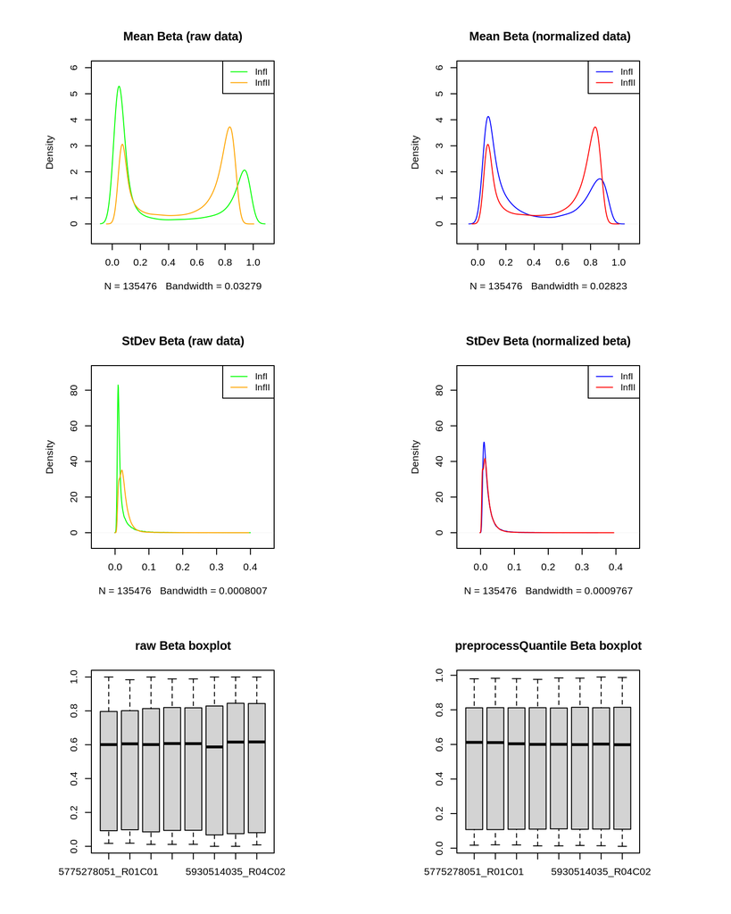

```r
# Mean beta raw
par(mfrow=c(3,2), pin = c(2,2))
plot(d_meanBetaI, col = "green", main = "Mean Beta (raw data)", xlim=c(-0.1,1.1),ylim = c(-0.5,6))
lines(d_meanBetaII, col = "orange")
legend("topright", legend=c("InfI", "InfII"),
       col=c("green", "orange"), lty=1:1, cex=0.9)
# Mean beta norm
plot(d_meanBeta_preprocessQuantile_I,col="blue",main=" Mean Beta (normalized data)", xlim = c(-0.1,1.1), ylim = c(-0.5
  ,6))
lines(d_meanBeta_preprocessQuantile_II,col="red")
legend("topright", legend=c("InfI", "InfII"),
       col=c("blue", "red"), lty=1:1, cex=0.9)
# sd beta raw
plot(d_sdBetaI, col = "green", main = "StDev Beta (raw data)", xlim = c(-0.05,0.45), ylim = c(-5,90))
lines(d_sdBetaII, col = "orange")
legend("topright", legend=c("InfI", "InfII"),
       col=c("green", "orange"), lty=1:1, cex=0.9)
# sd beta norm
plot(d_sdBeta_preprocessQuantile_I,col="blue",main="StDev Beta (normalized beta)", xlim = c(-0.05,0.45), ylim = c(-5
  ,90))
lines(d_sdBeta_preprocessQuantile_II,col="red")
legend("topright", legend=c("InfI", "InfII"),
       col=c("blue", "red"), lty=1:1, cex=0.9)
# beta raw
boxplot(beta,main="raw Beta boxplot")
# beta norm
boxplot(preprocessQuantileBeta, main = "preprocessQuantile Beta boxplot")
```

The most evident change we can observe in the plots (**Fig.4**) is between raw and normalized $\beta$ represented by the boxplot. After normalization we can note how the distributions are behaving almost identically. The only feature that behaves slightly different is the median. The plots referring to the density of the mean differ from each other in several ways: Infinium II raw mean beta distribution is shifted toward the center, while Infinium I raw mean beta distribution is less centered and closer to the edge of the graph. After normalization we can note how Infinium I mean distribution gets corrected and the first peak is reduced. Standard deviation has quite similar behaviour to the previous case: Infinium I raw standard deviation distribution has quite high peak, while Infinium II raw standard deviation distribution has a lower peak but more spread. After the normalization process with `preprocessQuantile()` function, we can notice a slightly increasing and shrinking of Infinium II standard deviation distribution behaviour and an evident reduction of the peak for Infinium I design. All those observed difference are due to the different chemistries that operate each design, indeed infinium I probes tend to have a larger span for beta values than Infinium II probe.

# 8 **PCA**

Next step we perform a PCA on the $\beta$ matrix generated in the normalization step. Principal components analysis is a method used with methylation data to identify predominant pattern of methylation along with the identified components, in this way samples with similar patterns clusterize together.

We use `prcomp()` function to extract the principal components.

```r
pca_results <- prcomp(t(preprocessQuantileBeta),scale=T)
print(summary(pca_results))
```

```
Importance of components:
                            PC1      PC2      PC3      PC4      PC5      PC6
Standard deviation     318.5898 302.3193 258.4334 244.4886 240.6867 234.1606
Proportion of Variance   0.2091   0.1883   0.1376   0.1231   0.1193   0.1129
Cumulative Proportion    0.2091   0.3973   0.5349   0.6580   0.7773   0.8902
                            PC7       PC8
Standard deviation     230.8501 1.388e-12
Proportion of Variance   0.1098 0.000e+00
Cumulative Proportion    1.0000 1.000e+00
```

The screeplot (obtained with `fviz_eig()` function) shows that the variance is descending through the components in a consistent manner. Indeed the proportion of the components is fairly similar, the first 7 components account for the total of the variance (100%). Plotting the first two components would account only for almost 40% of the total variance, it could be not enough to make assumptions.

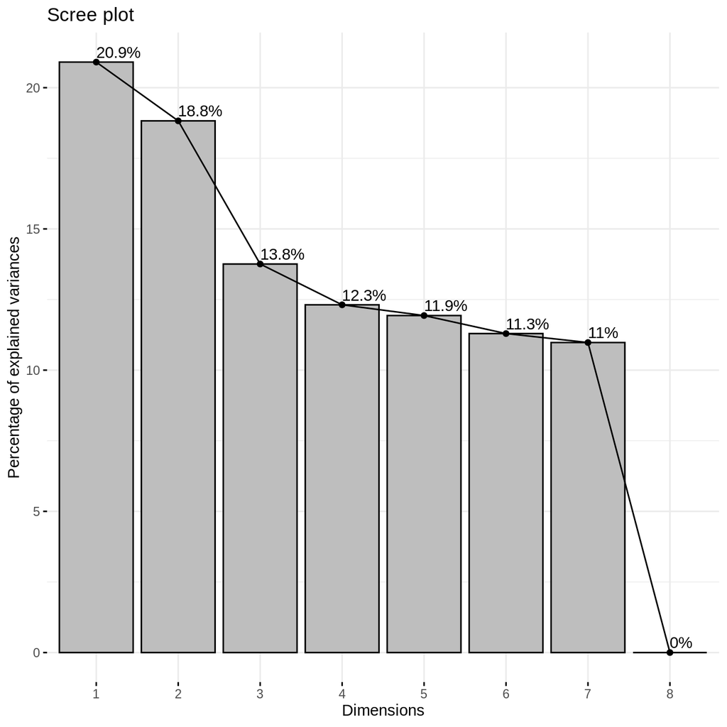

**Figure 5** : Screeplot of PCA results

```r
library(factoextra)
fviz_eig(pca_results, addlabels = TRUE, barfill = "grey", barcolor = "black")
```

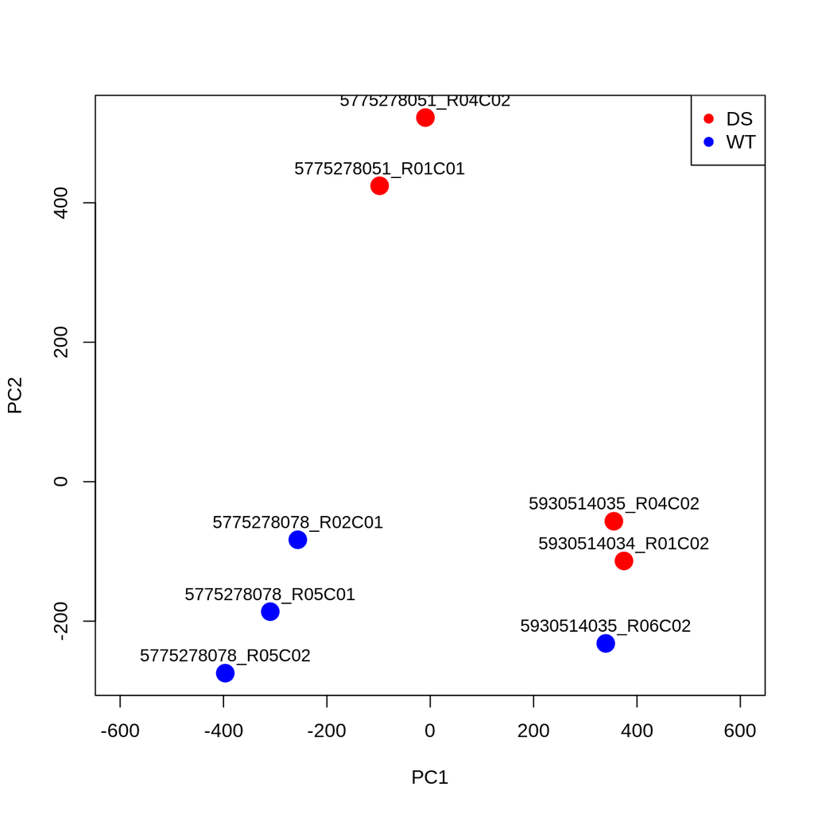

**Figure 6** : PCA results

```r
group <- factor(targets$Group)
palette(c("red", "blue"))
plot(pca_results$x[,1], pca_results$x[,2],cex=2,pch=19, col=c(group),xlab="PC1",ylab="PC2", xlim = c(-600, 600))
text(pca_results$x[,1], pca_results$x[,2],labels=rownames(pca_results$x),cex=0.9,pos=3)
legend("topright",legend=c("DS","WT"),col=c("red","blue"),pch=19)
```

We plot the first two components, labelling each point to the slide array in order to see the level of the batch effect. The plot shows no outliers, the results are clustered by the slide array and a diagonal line of $y=-ax$ divides the samples in the two groups (`WT` and `DS`). In the first case we can address the event to a probable presence of the batch effect. One thing that could have been done to avoid this is to randomize the sample in the array.

# 9 **Identification of differently methylated probes**

The following step will be performed using a `t-test` to identify differently mathylated probes between `DS` and `WT` samples. We will use the matrix with normalized $\beta$ values generated in **Chapter 7**.

We define a function `t_test_func()` that allows to perform a t-test to each row of the matrix. This function implements the `t.test()` function and then it returns the resulted p-value.

```r
t_test_func <- function(x) {
  t_test <- t.test(x~ csvtargets$Group)
    return(t_test$p.value)
}
pValues_ttest <- apply(preprocessQuantileBeta,1, t_test_func)
```

# 10 **Multiple test correction**

Multiple comparisons (such as the one just performed) has a downside: it allows an increase of the $\alpha$ level, therefore the probability of falsely rejecting the null hypotheses increases while testing. In order to overcome this problem we need to *adjust* the raw p-values just computed. We have two main correction method we can apply: *Bonferroni correction* {`bonferroni`} and *False Discovery Rate* {`BH`}. We apply both with `p.adjust()` function, once with `bonferroni` correction method and once with `BH` correction method.

```r
NormBeta_pValues <- data.frame(preprocessQuantileBeta, pValues_ttest)
NormBeta_pValues <- NormBeta_pValues[order(NormBeta_pValues$pValues_ttest),]

pValues_raw <- NormBeta_pValues$pValues_ttest
# bonferroni correction applied on raw p-values
pValues_ttest_bonf <- p.adjust(pValues_raw,"bonferroni")
# Benjamini-Hochberg correction applied on raw p-values
pValues_ttest_BH <- p.adjust(pValues_raw, "BH")

NormBeta_pValues <- data.frame(NormBeta_pValues, pValues_ttest_BH, pValues_ttest_bonf)
```

## 10.1 *significant p-values*

> **Q1**: How many probes do you identify as differentially methylated considering nominal pValues? **Q2**: How many after `Bonferroni` correction? **Q3**: How many after `BH` correction?

To answer those questions we need to find all those p-values that are smaller than a given threshold. Our threshold is set at `0.05` value.

```r
# Q1
dim(NormBeta_pValues[NormBeta_pValues$pValues_ttest<=0.05,])
```

```
[1] 39186    11
```

```r
# Q2
dim(NormBeta_pValues[NormBeta_pValues$pValues_ttest_bonf<=0.05,])
```

```
[1]  0 11
```

```r
# Q3
dim(NormBeta_pValues[NormBeta_pValues$pValues_ttest_BH<=0.05,])
```

```
[1]  0 11
```

### 10.1.1 Table recap

| p-Values | Number of significant samples |
| --- | --- |
| Raw | 39186 |
| Bonferroni correction | 0 |
| BH correction | 0 |

As we can see from the recap table above, the significant probes found taking into account raw p-value are `39186`, while for both *Bonferroni* and *BH* corrected p-values there were no significant probe found.

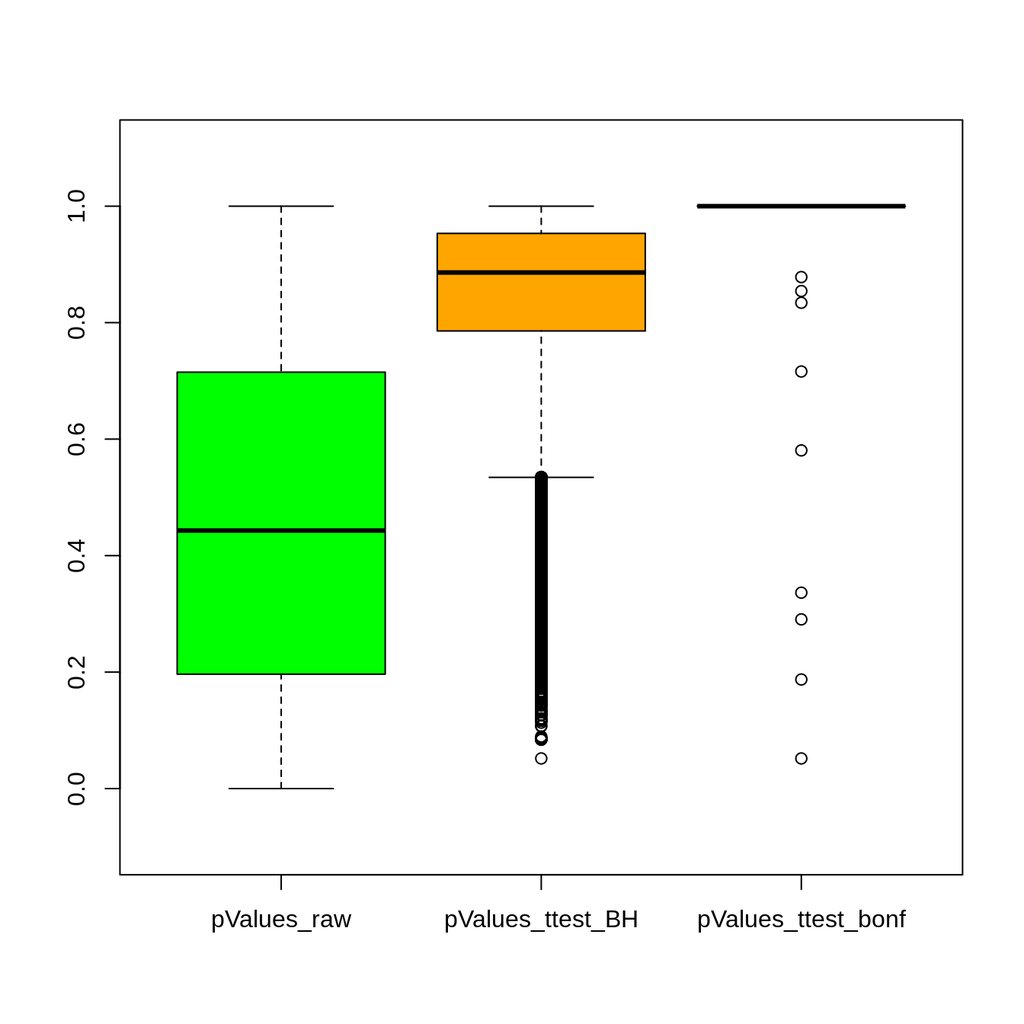

**Figure 7** : Boxplot of t-test results.

```r
ttest_df <- data.frame(pValues_raw, pValues_ttest_BH, pValues_ttest_bonf)
boxplot(ttest_df, ylim = c(-0.1, 1.1), col = c("green", "orange", "cyan"))
```

# 11 **Heatmap**

Heatmaps are useful tools to observe methylation levels in samples, different colors express different level of methylation. Similar expressions will cluster together and will have similar color. To generate the heatmap we use the `heatmap.2()` function with `complete`, `single` and `average` linkage on the top 100 differentially methylated probes.

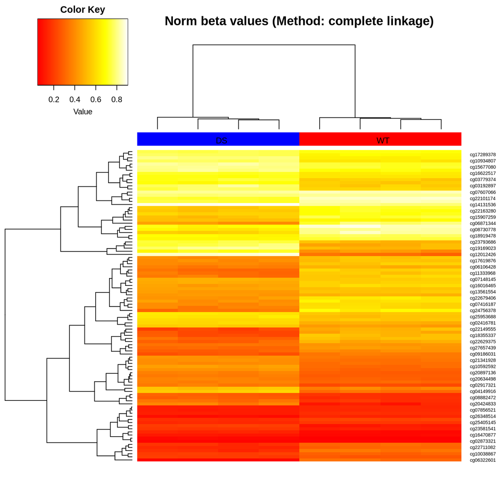

**Figure 8**: heatmap with complete linkage method

```r
library(gplots)
library(RColorBrewer)
library(gridExtra)

# taking only beta values of top 100 differentialy methylated probes
heatmap = as.matrix(NormBeta_pValues[1:100, 1:8])
colorbar <- c("blue","blue","red","red","red","blue", "blue", "red")

palette <- heat.colors(100)

# complete linkage
heatmap.2(heatmap, col= palette , Rowv=T, Colv=T, dendrogram="both", key=T, ColSideColors=colorbar, labCol = TRUE, density.info="none", trace="none", scale="none", symm=F, main = "Norm beta values (Method: complete linkage)")
text(x = c(0.4, 0.78), y = 0.77,
     labels = c('DS', 'WT'),
     col = 'black',
     cex = 0.8,
     las = 2,
     xpd = TRUE)
```

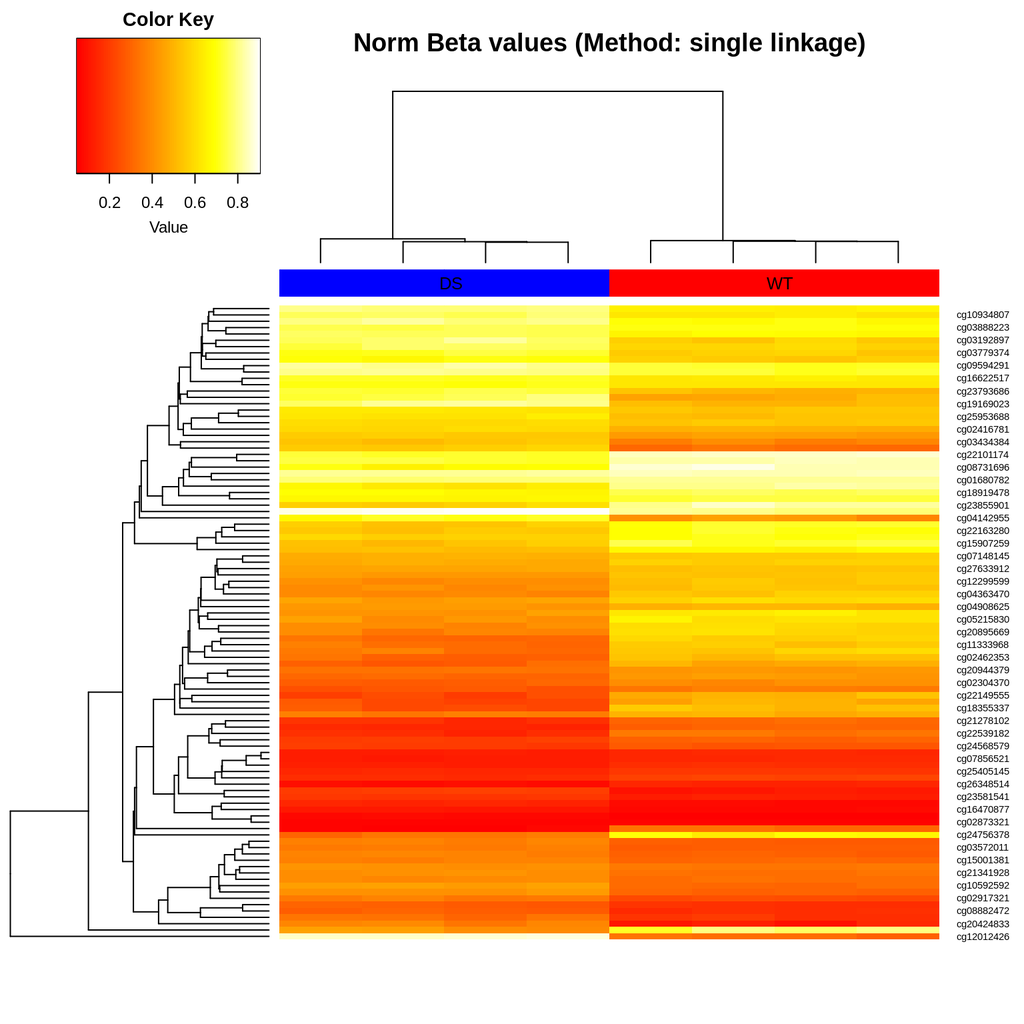

**Figure 9**: heatmap with single linkage method

```r
# single linkage
heatmap.2(heatmap, col= palette , Rowv=T, Colv=T, hclustfun = function(x) hclust(x, method = 'single'), dendrogram ="both", key=T, ColSideColors=colorbar, labCol = TRUE, density.info="none", trace="none", scale="none", symm=F, main = "Norm Beta values (Method: single linkage)")
text(x = c(0.4, 0.78), y = 0.774,
     labels = c('DS', 'WT'),
     col = 'black',
     cex = 0.8,
     las = 2,
     xpd = TRUE)
```

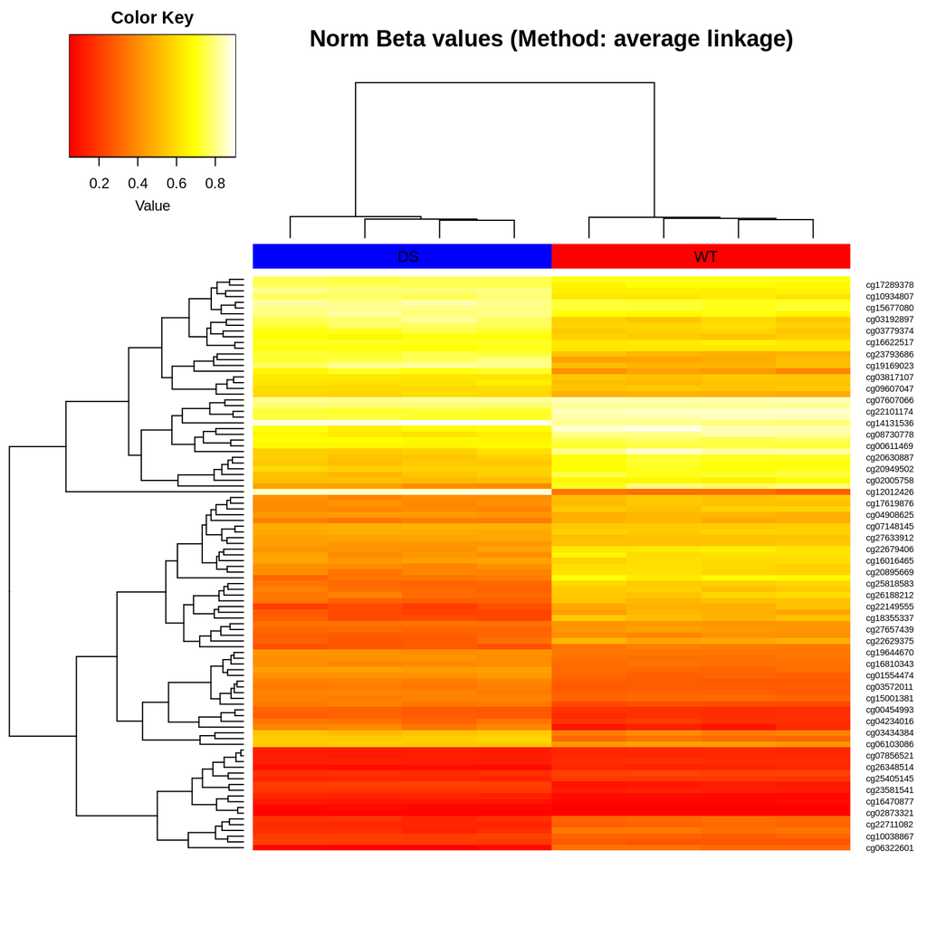

**Figure 10**: heatmap with average linkage method

```r
# averge linkage
heatmap.2(heatmap, col= palette, Rowv=T, Colv=T, hclustfun = function(x) hclust(x,method = 'average'), dendrogram ="both", key=T, ColSideColors=colorbar, labCol = TRUE, density.info="none", trace="none", scale="none", symm=F, main = "Norm Beta values (Method: average linkage)")
text(x = c(0.4, 0.78), y = 0.774,
     labels = c('DS', 'WT'),
     col = 'black',
     cex = 0.8,
     las = 2,
     xpd = TRUE)
```

As we can see in **Figures 8, 9** and **10** different linkage methods don’t influence the results that much: both groups maintain the clusterization, there are no visible difference in methylation level besides some cases where some probe resulted more methylated than others. The latter case is most prominent in the case of `cg12012426` that results highly methylated for `DS` but very low methylation in the other group.

# 12 **Additional plots**

Additional plots such as **Volcano plot** and **Manhattan plot** are useful to better visualize results of differential methylation analysis.

## 12.1 *Volcano plot*

```r
NormBeta <- NormBeta_pValues[, 1:8]

# DS
NormBeta_DS <- NormBeta[, csvtargets$Group == "DS"]
meanNormBeta_DS <- apply(NormBeta_DS, 1, mean)
# WT
NormBeta_WT <- NormBeta[, csvtargets$Group == "WT"]
meanNormBeta_WT <- apply(NormBeta_WT, 1, mean)
# delta
delta <- meanNormBeta_DS-meanNormBeta_WT

# Volcano plot raw data
VolcPlot_raw <- data.frame(delta, -log10(NormBeta_pValues$pValues_ttest))
Highlight_raw <- VolcPlot_raw[abs(VolcPlot_raw[, 1])>0.1 & VolcPlot_raw[, 2]>(-log10(0.05)),]
# Volcano plot bonf corrected data
VolcPlot_bonf <- data.frame(delta, -log10(NormBeta_pValues$pValues_ttest_bonf))
Highlight_bonf <- VolcPlot_bonf[abs(VolcPlot_bonf[, 1])>0.1 & VolcPlot_bonf[, 2]>(-log10(0.05)),]
# Volcano plot BH corrected data
VolcPlot_BH <- data.frame(delta, -log10(NormBeta_pValues$pValues_ttest_BH))
Highlight_BH <- VolcPlot_BH[abs(VolcPlot_BH[,1])>0.1 & VolcPlot_BH[,2]>(-log10(0.05)),]

par(mfrow = c(1,3))
# plot Volcano plot raw
plot(VolcPlot_raw[,1], VolcPlot_raw[,2], pch=16, cex=0.5, ylab="raw p-Values (-log)", xlab="delta",ylim = c(0, 7)) -log10(0.05)
```

```r
abline(a=-log10(0.05),b=0,col="red")
points(Highlight_raw[,1], Highlight_raw[,2],pch=16,cex=0.7,col="red")

# plot Volcano plot bonf
plot(VolcPlot_bonf[,1], VolcPlot_bonf[,2], pch=16,cex=0.5, ylab="bonf corrected p-Values (-log)", xlab="delta", ylim = c(0, 7)) -log10(0.05)
```

```r
abline(a=-log10(0.05),b=0,col="red")
points(Highlight_bonf[,1], Highlight_bonf[,2],pch=16,cex=0.7,col="red")

# plot Volcano plot BH
plot(VolcPlot_BH[,1], VolcPlot_BH[,2], pch=16,cex=0.5, ylab="BH corrected p-Values (-log)", xlab="delta", ylim = c(0, 7)) -log10(0.05)
```

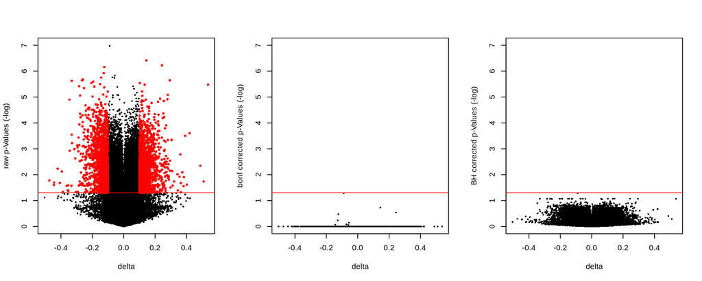

**Figure 11**: (from left) Volcano plot with raw p-value, bonferroni corrected p-value and BH corrected p-value

```r
abline(a=-log10(0.05),b=0,col="red")
points(Highlight_BH[,1], Highlight_BH[,2],pch=16,cex=0.7,col="red")
```

## 12.2 *Manhattan plot*

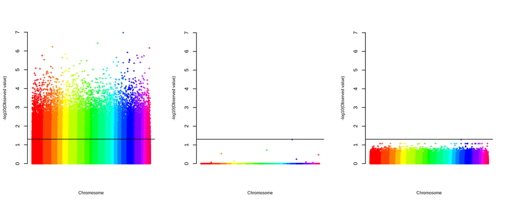

**Figure 12**: (from left) Manhattan plot with raw p-value, bonferroni corrected p-value and BH corrected p-value

```r
library(gap)
NormBeta_pValues_inv <-data.frame(rownames(NormBeta_pValues), NormBeta_pValues)
colnames(NormBeta_pValues_inv)[1] <- "IlmnID"

# we need to annotate the data
NormBeta_pValues_ann <- merge(NormBeta_pValues_inv, Illumina450Manifest_clean, by="IlmnID")
NormBeta_pValues_ann <- droplevels(NormBeta_pValues_ann)

Manhattan_raw <- data.frame(NormBeta_pValues_ann$CHR, NormBeta_pValues_ann$MAPINFO, NormBeta_pValues_ann$pValues_ttest)
Manhattan_bonf <- data.frame(NormBeta_pValues_ann$CHR, NormBeta_pValues_ann$MAPINFO, NormBeta_pValues_ann$pValues_ttest_bonf)
Manhattan_BH <- data.frame(NormBeta_pValues_ann$CHR, NormBeta_pValues_ann$MAPINFO, NormBeta_pValues_ann$pValues_ttest_BH)

Manhattan_raw$NormBeta_pValues_ann.CHR <- factor(Manhattan_raw$NormBeta_pValues_ann.CHR, levels = c("1","2","3","4","5","6","7","8","9","10","11","12","13","14","15","16","17","18","19","20","21","22","X","Y"))
Manhattan_bonf$NormBeta_pValues_ann.CHR <- factor(Manhattan_bonf$NormBeta_pValues_ann.CHR, levels = c("1","2","3","4","5","6","7","8","9","10","11","12","13","14","15","16","17","18","19","20","21","22","X","Y"))
Manhattan_BH$NormBeta_pValues_ann.CHR <- factor(Manhattan_BH$NormBeta_pValues_ann.CHR, levels = c("1","2","3","4","5","6","7","8","9","10","11","12","13","14","15","16","17","18","19","20","21","22","X","Y"))


palette <- rainbow(24)

par(mfrow = c(1, 3))
# Manhattan plot raw p-values
mhtplot(Manhattan_raw,control=mht.control(colors=palette))
axis(2,cex=0.5)
abline(a=-log10(0.05),b=0)
# Manhattan plot bonf corrected p-values
mhtplot(Manhattan_bonf,control=mht.control(colors=palette), ylim = c(0,7))
axis(2,cex=0.5)
abline(a=-log10(0.05),b=0)
# Manhattan plot BH corrected p-values
mhtplot(Manhattan_BH,control=mht.control(colors=palette), ylim = c(0,7))
axis(2,cex=0.5)
abline(a=-log10(0.05),b=0)
```

Both sets of plots (**Figures 11 and 12**) are consistent with previous analysis, indeed we can highlight probes below significant threshold only in non corrected p-values case, while no probes are highlighted in both bonferroni and BH corrected p-value.

# 13 **Focus on chromosome 21**

Down syndrome is caused by the trisomy of chromosome 21, in this final step we will perform an in depht analysis to visualize if there are any difference in methylation between `DS` sample group and `WT` specifically on chromosome 21. We will perform this task by plotting normalized $\beta$ values by the annotated object we generated in the previous step and cross-reference it with the normalized $\beta$ values in order to retain only those associated to chromose 21. Then we subset the beta values in `WT` and `DS` as we did in the **chapter 6**, we compute `mean` and `densities` for both subsets and we plot it (**Figure 13**).

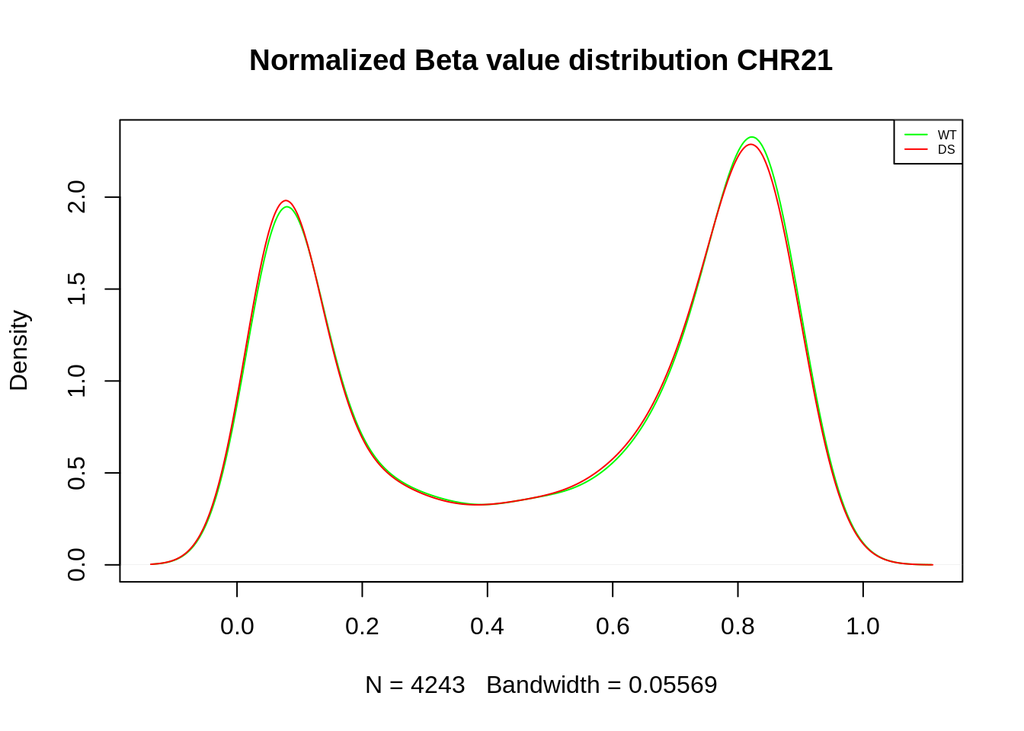

**Figure 13**: Chromosome 21 $\beta$ density distribution

```r
chr21 <- NormBeta_pValues_ann[NormBeta_pValues_ann$CHR == "21",]
chr21 <- droplevels(chr21)
beta_21 <- preprocessQuantileBeta[rownames(preprocessQuantileBeta) %in% chr21$IlmnID,]

#WT
beta_wt_21 <- beta_21[, colnames(beta_21) %in% WT]
mean_beta_wt_21 <- apply(beta_wt_21, 1, mean)
d_mean_beta_wt_21 <- density(mean_beta_wt_21, na.rm = T)

#DS
beta_ds_21 <- beta_21[, colnames(beta_21) %in% DS]
mean_beta_ds_21 <- apply(beta_ds_21, 1, mean)
d_mean_beta_ds_21 <- density(mean_beta_ds_21, na.rm = T)

plot(d_mean_beta_wt_21, col = "green", main = "Normalized Beta value distribution CHR21")
lines(d_mean_beta_ds_21, col = "red")
legend("topright", legend=c("WT", "DS"),
       col=c("green", "red"), lty=1:1, cex=0.5)
```

We can note that there isn’t much difference between the two groups, the distributions follow almost the same curve trend besides `WT` distribution having a slightly higher peak than the `DS` curve on high values for $\beta$ .

> **Q**: How many differentially methylated probes do you find on chromosome 21?

To answer this question we will simply use the `dim()` function on the dataset that contains p-values associated to chromosome 21. We use `raw_pvalues`, and both corrected versions `bonf_pValues` and `BH_pValues`.

```r
dim(chr21[chr21$pValues_ttest <= 0.05,])
```

```
[1] 598  44
```

```r
dim(chr21[chr21$pValues_ttest_BH <= 0.05,])
```

```
[1]  0 44
```

```r
dim(chr21[chr21$pValues_ttest_bonf<= 0.05,])
```

```
[1]  0 44
```

## 13.1 *Table recap*

Results are recapped in the following table:

| p-values | differentially methylated probes |
| --- | --- |
| raw | 598 |
| bonferroni | 0 |
| BH | 0 |

Consistently with the previous results, we found differentially methylated probes only if taking into account raw p -values.